### The biological interpretation (E) of redox imaging displays regions of differing sensitivity to changes in the directly-measured values (R).

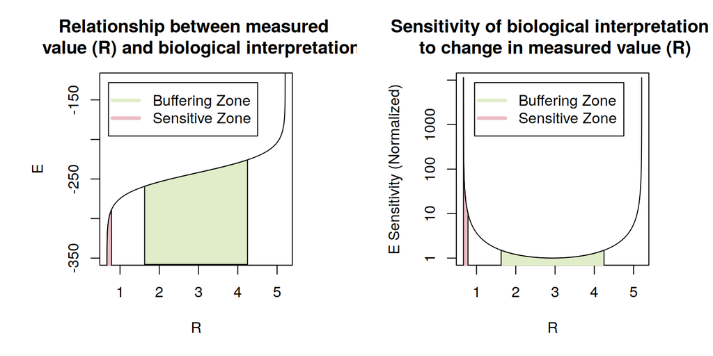

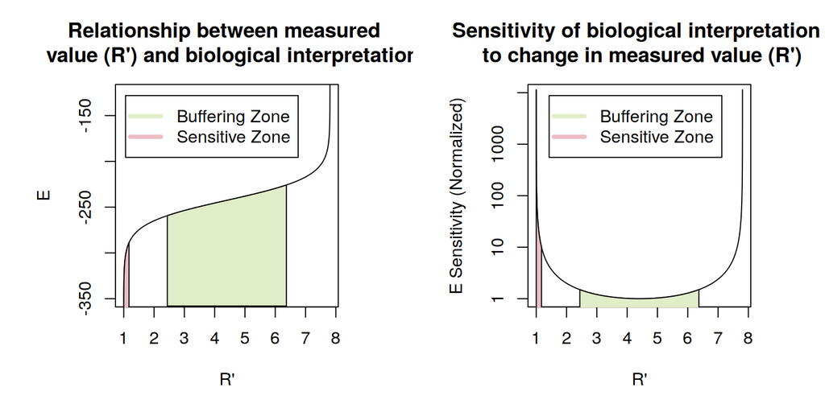

Note that the electrical potential $E$ is related to $R$ via $E^\circ$ , $R_{min}$, $R_{max}$, and $\delta$:
$$E = E^\circ - \frac{RT}{2F}ln(\frac{1- \frac{R-R_{min}}{(R-R_{min})-\delta(R_{max}-R)}}{\frac{R-Rmin}{(R-R_{min})-\delta(R_{max}-R)}}) = \\ E^\circ - \frac{RT}{2F}ln(\frac{\delta*(R_{max}-R)}{R-R_{min}})$$
.

But the derivative of the electrical potential $E$ with respect to $R$ is only dependent on the $R_{min}$ and $R_{max}$:
$$\frac{\partial E}{\partial R} = \frac{-RT}{2F}*\frac{R_{max}-R_{min}}{(R-R_{min})(R-R_{max})}$$

In other words, the relative dynamic range in each channel ($\delta_\lambda$) has no effect on the sensitivity of the biological interpretation to a change in measured value. The error will be minimized when the measured value $R$ is exactly in the middle of the maximum possible value $R_{max}$ and the minimum possible value $R_{min}$. As the measured value approaches either of the extremes, the error asymptotically approaches infinity.

### Translating from general sensitivity (in the previous section) to the particular errors in biological interpretation, given a relative or absolute error in the directly-measured value.

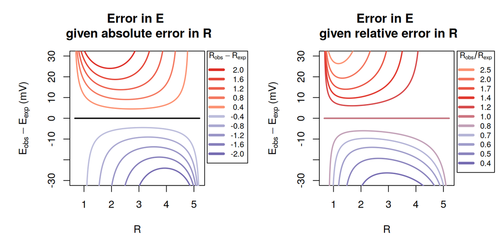

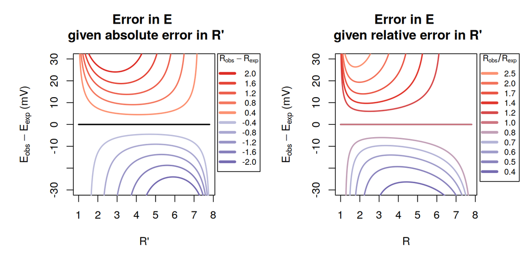

Following from the math in the previous section, changing the $\delta_\lambda$ of the sensor will have no effect on these graphs. Changing the overall dynamic range will scale the graphs, but the general shape of the plot will stay constant.

### Errors within biologically meaningful errors in R

The following is assuming that the “biologically relevant region” is between -260 and -280:

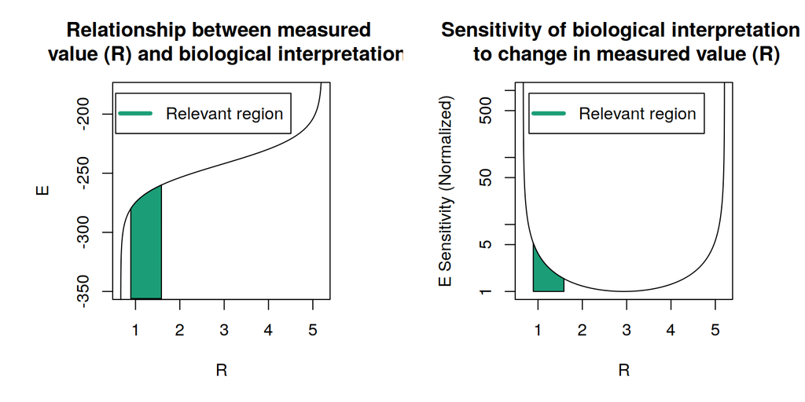

```
## [1] "The biologically relevant values of R range from 0.8937 to 1.5849"
```

Based roughly on the response to reviewers, 95% confidence intervals in R seem to be on the order of ~0.1. With that level of accuracy, how much error in R can we expect?

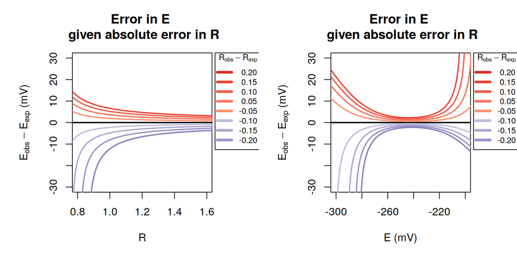

### Generalizing for sensor characteristics

Let’s take a plot of the normalized deriviative of E for sensors with different qualities and plot that on a graph with E on the x axis (instead of R).

1. E0 = -265, Rmin = 0.667, Rmax = 5.207,delta = .171
2. E0 = -270, Rmin = 1, Rmax = 2, delta = 1 – Midpoint potential in our range, but low dynamic range
3. E0 - -290, Rmin = 1, Rmax = 12, delta = 1 – Midpoint potential not in our range, but high dynamic range
4. E0 - -290, Rmin = 1, Rmax = 12, delta = 3 – Same as 3, but higher delta
5. E0 - -290, Rmin = 1, Rmax = 12, delta = 0.1 – Same as 3, but lower delta

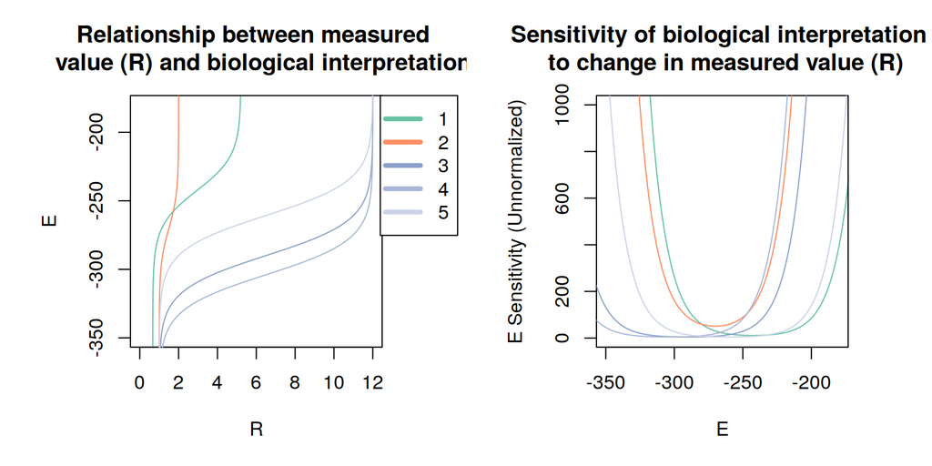

Replotting the derivative within the relevant range:

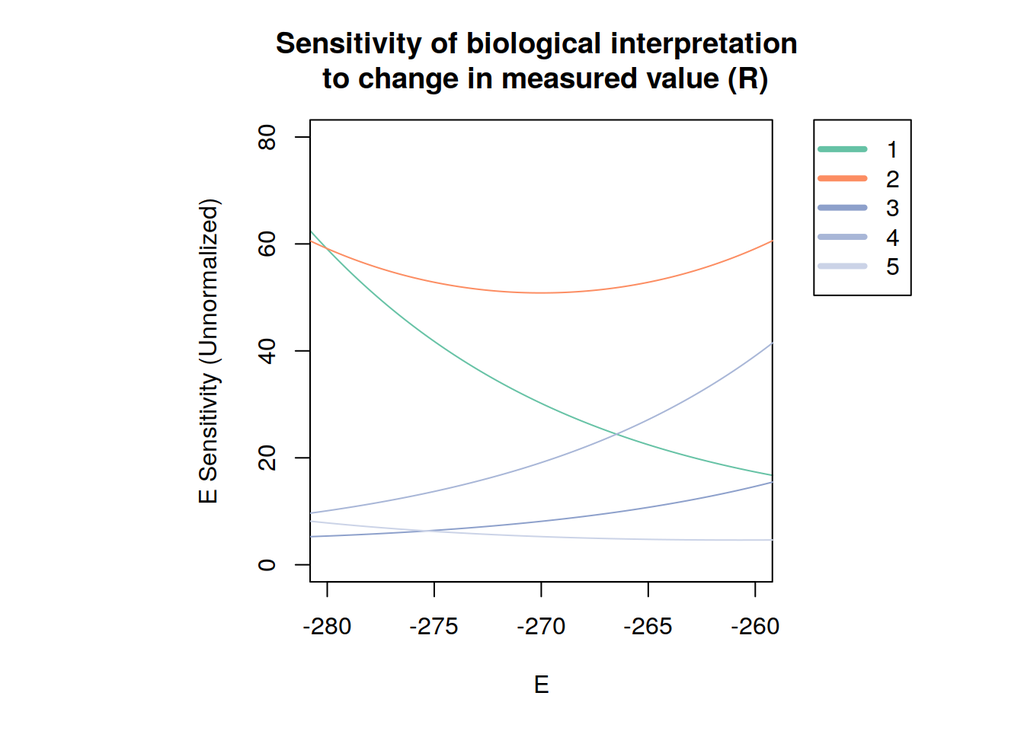

We can show that, for this range of E values, the sensor with the large dynamic range performs with the lowest sensitivity, even though its midpoint potential is furthest from the center of our biologically-relevant range

But notice that, in this view, delta does matter. Delta changes the mapping of R values to E values and therefore, while it does not change the sensitivity of E at any given R, it changes the E value that corresponds to that R.

The sensor has minimal error at the point where OxD is 0.5. Changing the delta value can change the voltage level at which that point occurs. Notice that, we if zoom out of the previous graph, you can see that the minimum sensitivity changes between sensors 1, 2, and {3,4,5}, but the changes in delta just translate the curve along the horizontal axis:

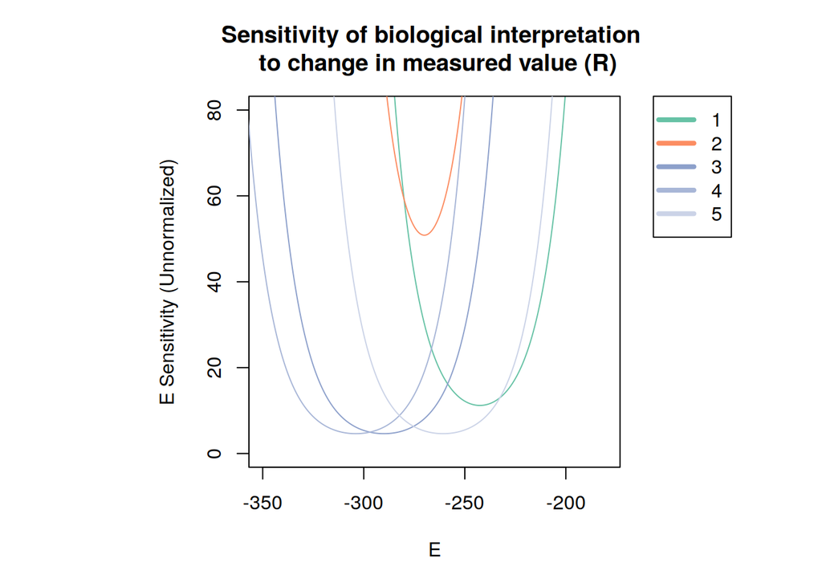

From earlier, we know that
$$E^\circ - \frac{RT}{2F}ln(\frac{\delta*(R_{max}-R)}{R-R_{min}})$$
.

And we know that the minimum error occurs when $R = \frac{R_{max}+R_{min}}{2}$

We can also approximate $\frac{RT}{2F} = 12.71$ at our conditions

So, for example, the minimum error for Sensor 3, 4, and 5 is
$$-290 - 12.71ln(\frac{\delta*(12-6.5)}{6.5-1})$$
.

When $\delta = 1$, like in Sensor 3, then
$$-290 - 12.71ln(\frac{1*(12-6.5)}{6.5-1}) = -290 - 12.71ln(1) = -290mV$$

Generalizing, any delta changes the midpoint by a scale of $ln(\delta)*\frac{RT}{2F} = ln(\delta)*12.71$

So we would expect that changing the delta to 3, as we did with sensor 4, would decrease point of minimum error by $ln(3) * 12.71 = 13.96 mV$

And sure enough $-290 - 12.71ln(\frac{3*(12-6.5)}{6.5-1}) = -303.96mV = -290 - 13.96$

So, if you could create a sensor with any properties, you would: (1) Make a sensor with the greatest possible dynamic range possible, with a midpoint potential somewhere in the range of the desired values to be measured (2) Tweak the $\delta$ of that sensor so that the minimum error falls in the midpoint of the desired values to be measured.

In practice when comparing sensors, we can just compare integrative sensitivities of voltage over the range of voltage values that we want to measure.

If the above is true, then two sensors should have the exact same error profiles if they have the same characteristics except for: (1) The E values are different by a $12.71 * ln(*3*)$ and (2) The delta values are different by a factor of *3*

This appears to be true. Let’s look at two sensors that each have an Rmin of 1, Rmax of 6, but an E0 of -270 and -256 and a delta of 1 and 3 for sensor 1 and 2, respectively:

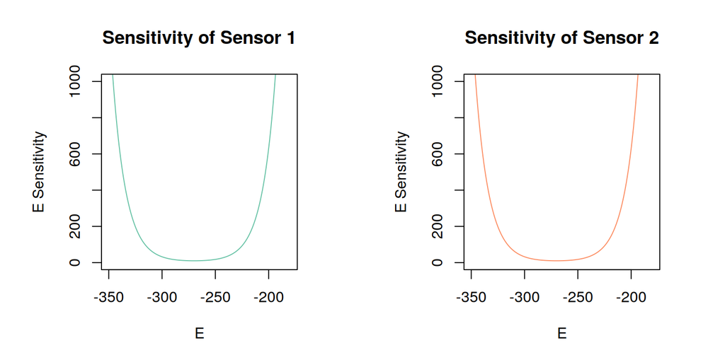